# R Notebook for *Quantitative Distribution of English and Indonesian Motion Verbs and Its Typological Implications: A case study with the English and Indonesian versions of the* Twilight *novel*

by* [Gede Primahadi Wijaya RAJEG](https://udayananetworking.unud.ac.id/lecturer/880-gede-primahadi-wijaya-rajeg) [^1] & Utei Charaleghy PAMPHILA[^2]

**keywords**: *open science*; *open notebook*; *open data*; *R programming*; *motion verbs*; *English*; *Indonesian*; *lexicalisation patterns*; *semantic typology*; *quantitative linguistics*

# 1 Load the frequency list data

Below are the codes to read in the frequency list data for the manner and path Verbs in the English and Indonesian versions of the novel *Twilight*. Readers need to install the [tidyverse](https://www.tidyverse.org) suit of R packages as the codes heavily use functionality from this package, in addition to the [RColorBrewer](https://cran.r-project.org/web/packages/RColorBrewer/index.html) package used in the visualisation codes.

```r
# Read in the manner verbs data in English and Indonesian
manner_eng_tokens <- readr::read_tsv("data-joll/manner_eng_tokens.txt") %>%
  arrange(desc(n), lemma)
manner_idn_tokens <- readr::read_tsv("data-joll/manner_idn_tokens.txt") %>%
  arrange(desc(n), lemma)

# Read in the path verbs data in English and Indonesian
path_eng_tokens <- readr::read_tsv("data-joll/path_eng_tokens.txt")
path_idn_tokens <- readr::read_tsv("data-joll/path_idn_tokens.txt")
```

# 2 Quantitative analyses

The codes below generate the data frame as the input for all figures/plots in the paper.

```r
mnr <- tibble(tokens = c(sum(manner_eng_tokens$n), sum(manner_idn_tokens$n)),
              perc_token = (tokens/sum(tokens)) * 100,
              type = c(nrow(manner_eng_tokens), nrow(manner_idn_tokens)),
              perc_type = (type/sum(type)) * 100,
              ttr = type/tokens,
              language = c("English", "Indonesian"),
              verb_type = "manner-verb")
pth <- tibble(tokens = c(sum(path_eng_tokens$n), sum(path_idn_tokens$n)),
              perc_token = (tokens/sum(tokens)) * 100,
              type = c(nrow(path_eng_tokens), nrow(path_idn_tokens)),
              perc_type = (type/sum(type)) * 100,
              ttr = type/tokens,
              language = c("English", "Indonesian"),
              verb_type = "path-verb")
```

The following codes combine the previous codes to generate data for extracting percentages of manner and path verbs out of the total motion verbs in English and Indonesian.

```r
mnr_pth <- bind_rows(mnr, pth) %>%
  group_by(language) %>%
  mutate(perc_token_lang = tokens/sum(tokens) * 100,
         perc_type_lang = type/sum(type) * 100,
         sum_type_lang = sum(type),
         sum_token_lang = sum(tokens)) %>%
  ungroup()

# print out the content of the `mnr_pth` data frame
mnr_pth
```

| tokens | perc_token | type | perc_type | ttr | language | verb_type | perc_token_lang | perc_type_lang | sum_type_lang | sum_token_lang |
| --- | --- | --- | --- | --- | --- | --- | --- | --- | --- | --- |
| 729 | 61.88455 | 65 | 71.42857 | 0.08916324 | English | manner-verb | 55.73394 | 79.26829 | 82 | 1308 |
| 449 | 38.11545 | 26 | 28.57143 | 0.05790646 | Indonesian | manner-verb | 33.38290 | 43.33333 | 60 | 1345 |
| 579 | 39.25424 | 17 | 33.33333 | 0.02936097 | English | path-verb | 44.26606 | 20.73171 | 82 | 1308 |
| 896 | 60.74576 | 34 | 66.66667 | 0.03794643 | Indonesian | path-verb | 66.61710 | 56.66667 | 60 | 1345 |

The `tokens` column contains the total token-frequency of the manner and path verbs for English and Indonesian. The `perc_token` column represents percentages of the values in the `tokens` column, that is, the percentages of manner and path verbs respectively by `language`. So for instance, the value 61.88% in the `perc_token` column represents the percentage of the English manner out of the total 1178 tokens of manner verbs across English and Indonesian. The same interpretation applies to the `type` and `perc_type` columns. The `ttr` column represents the Type-per-Token Ratio (TTR).

In our database of the English version of *Twilight*, we identified 82 types of MOTION verbs in general. From this total of English MOTION verbs (N<sub>type</sub> <sub>motion</sub> = 82), 79.27% repesent the manner verbs and the remaining 20.73% are the path verbs. When we look at the Indonesian database of *Twilight*, the total number of the Indonesian MOTION verbs (N<sub>type</sub> <sub>motion</sub> = 60) is lower than that of English (N<sub>type</sub> <sub>motion</sub> = 82), though it is not a significant difference (*p*<sub>binomial</sub> = 0.078). From the total of 60 Indonesian MOTION verbs, the Indonesian manner verbs constitute 43.33% of that total, while the Indonesian path verbs take the remaining 56.67%.

The codes below demonstrate how these percentages are extracted from the `mnr_pth` data frame.

```r
# percentage of manner and path verbs out of the total motion verbs in English and Indonesian

## % of the English manner verbs
mnr_pth %>% filter(language == "English", verb_type == "manner-verb") %>% pull(perc_type_lang) %>% round(2)

## % of the English path verbs
mnr_pth %>% filter(language == "English", verb_type == "path-verb") %>% pull(perc_type_lang) %>% round(2)

## % of the Indonesian manner verbs
mnr_pth %>% filter(language == "Indonesian", verb_type == "manner-verb") %>% pull(perc_type_lang) %>% round(2)

## % of the Indonesian path verbs
mnr_pth %>% filter(language == "Indonesian", verb_type == "path-verb") %>% pull(perc_type_lang) %>% round(2)

## p-value of the Exact Binomial Test (two-tailed) for comparing the number of MOTION verbs between English and Indonesian
round(binom.test(c(unique(pull(filter(mnr_pth, language == "English"), sum_type_lang)),
                   unique(pull(filter(mnr_pth, language == "Indonesian"), sum_type_lang))))$p.value, 3)

## Get the total number of MOTION verbs in the English database
unique(pull(filter(mnr_pth, language == "English"), sum_type_lang))

## Get the total number of MOTION verbs in the Indonesian database
unique(pull(filter(mnr_pth, language == "Indonesian"), sum_type_lang))
```

## 2.1 Manner verbs

### 2.1.1 Binomial test for type frequencies

The following codes demonstrate the calculation of *p*-value of the Exact Binomial Test (two-tailed) for the type-frequencies comparison of manner verbs between English and Indonesian.

```r
# get the number of manner verbs in Indonesian and English
sum_manner_idn_types <- nrow(manner_idn_tokens)
sum_manner_eng_types <- nrow(manner_eng_tokens)

# run the binomial test (two-tailed)
binom_manner_types <- binom.test(c(sum_manner_idn_types, sum_manner_eng_types))

# output only the p-value
binom_manner_types$p.value
```

```
[1] 5.311763e-05
```

As we see, the *p*-value is very small (*p* < 0.001).

### 2.1.2 Binomial test for token frequencies

The following codes demonstrate the calculation of *p*-value of the Exact Binomial Test (two-tailed) for the token-frequencies comparison of manner verbs between English and Indonesian.

```r
# get the summed token-frequencies of the manner verbs in Indonesian and English
sum_manner_idn_tokens <- sum(manner_idn_tokens$n)
sum_manner_eng_tokens <- sum(manner_eng_tokens$n)

# run the binomial test (two-tailed)
binom_manner_tokens <- binom.test(c(sum_manner_idn_tokens, sum_manner_eng_tokens))

# output only the p-value
binom_manner_tokens$p.value
```

```
[1] 3.158974e-16
```

As we see, the *p*-value is very small (*p* < 0.001).

### 2.1.3 Type-per-token Ratio (TTR)

The TTR value of the English manner verbs (TTR<sub>English</sub> = 0.0892) is higher than that of Indonesian (TTR<sub>Indonesian</sub> = 0.0579), suggesting a greater lexical diversity of the Manner verbs inventory in English.

### 2.1.4 Visualisations

The following codes produce **Figure 1** in the paper.

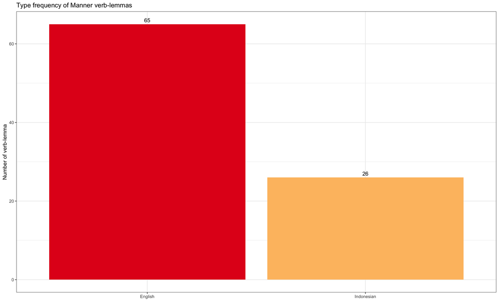

```r
mnr %>%
  ggplot(aes(x = language, y = type)) +
  geom_col(fill = RColorBrewer::brewer.pal(12, name = "Paired")[6:7]) +
  geom_text(aes(label = type), vjust = -.5) +
  theme_bw() +
  labs(y = "Number of verb-lemma", x = "", title = "Type frequency of Manner verb-lemmas") +
  ggsave("figs-joll/total-type-of-manner-verbs.png", width = 6, height = 5)
```

The following codes produce **Figure 2** in the paper.

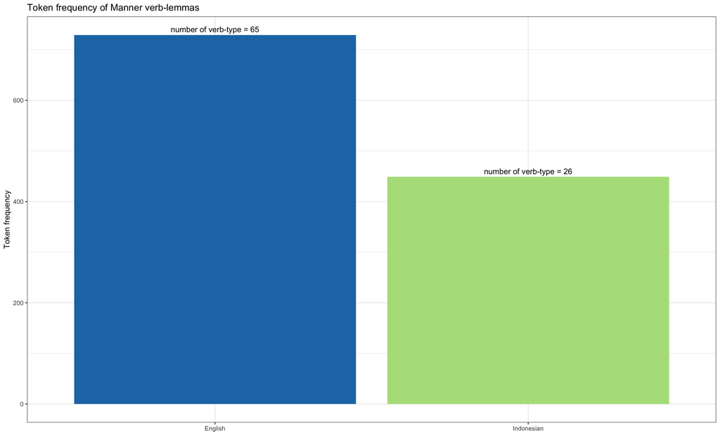

```r
mnr %>%
  ggplot(aes(x = language, y = tokens)) +
  geom_col(fill = RColorBrewer::brewer.pal(12, name = "Paired")[2:3]) +
  geom_text(aes(label = paste("number of verb-type = ", type, sep = "")), vjust = -.5) +
  theme_bw() +
  labs(y = "Token frequency", x = "", title = "Token frequency of Manner verb-lemmas") +
  ggsave("figs-joll/total-tokens-of-manner-verbs.png", width = 6, height = 5)
```

### 2.1.5 Data in Table 1

Here are the codes to generate the content of the cells in **Table 1** in the paper.

```r
mnr_idn_gloss <- c("walk", "run", "stride; take a step", "jump", "drive", "dash; rush", "slide/glide away", "glide/float in/through the air", "move along at a high speed", "sneak (into)", "race; move fast", "break through; force one's way into", "crawl", "hop up and down", "slip/slide away", "stroll around", "swing", "tiptoe", "fly", "stumbled; tripped over", "swim", "bounce around; jump repeatedly", "rock; sway; wave", "stalk", "slip/slide away", "fall headlong; slip/slide away")
eng_mnr_cell <- paste(paste("*", manner_eng_tokens$lemma, "*", " (", manner_eng_tokens$n, ")", sep = ""), collapse = ", ")
idn_mnr_cell <- paste(paste("*", manner_idn_tokens$lemma, "*", " '", mnr_idn_gloss, "' (", manner_idn_tokens$n, ")", sep = ""), collapse = ", ")
tibble(`---` = c("ENGLISH ...", eng_mnr_cell, "INDONESIAN ...", idn_mnr_cell)) %>%
  knitr::kable(caption = "Manner verb-lemmas and their token frequencies in *Twilight*")
```

Manner verb-lemmas and their token frequencies in *Twilight*

[output not shown]

```r
NA
```

## 2.2 Path verbs

### 2.2.1 Binomial test for type frequencies

Below are the codes to run the Exact Binomial Test (two-tailed) for the type-frequency comparison of path verbs between English and Indonesian. The resulting *p*-value is small (*p* < 0.05).

```r
binom_path <- binom.test(c(nrow(path_idn_tokens), nrow(path_eng_tokens)))
binom_path$p.value
```

```
[1] 0.02409291
```

### 2.2.2 Binomial test for token frequencies

The following codes demonstrate the calculation of *p*-value of the Exact Binomial Test (two-tailed) for the token-frequencies comparison of path verbs between English and Indonesian. The resulting *p*-value is also very small (*p* < 0.001)

```r
binom_path_tokens <- binom.test(c(sum(path_idn_tokens$n), sum(path_eng_tokens$n)))
binom_path_tokens$p.value
```

```
[1] 1.463217e-16
```

### 2.2.4 Visualisations

The following codes produce **Figure 3** in the paper.

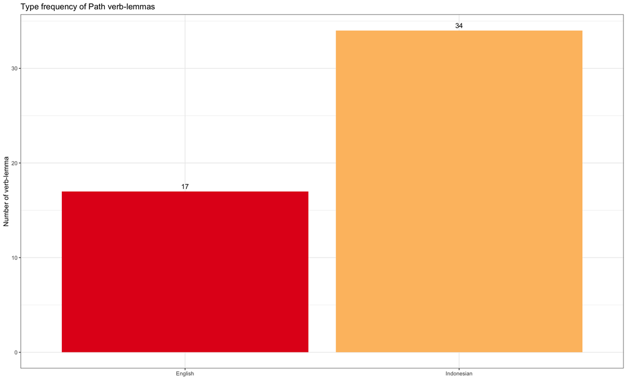

```r
pth %>%
  ggplot(aes(x = language, y = type)) +
  geom_col(fill = RColorBrewer::brewer.pal(12, name = "Paired")[6:7]) +
  geom_text(aes(label = type), vjust = -.5) +
  theme_bw() +
  labs(y = "Number of verb-lemma", x = "", title = "Type frequency of Path verb-lemmas") +
  ggsave("figs-joll/total-type-of-path-verbs.png", width = 6, height = 5)
```

The following codes produce **Figure 4** in the paper.

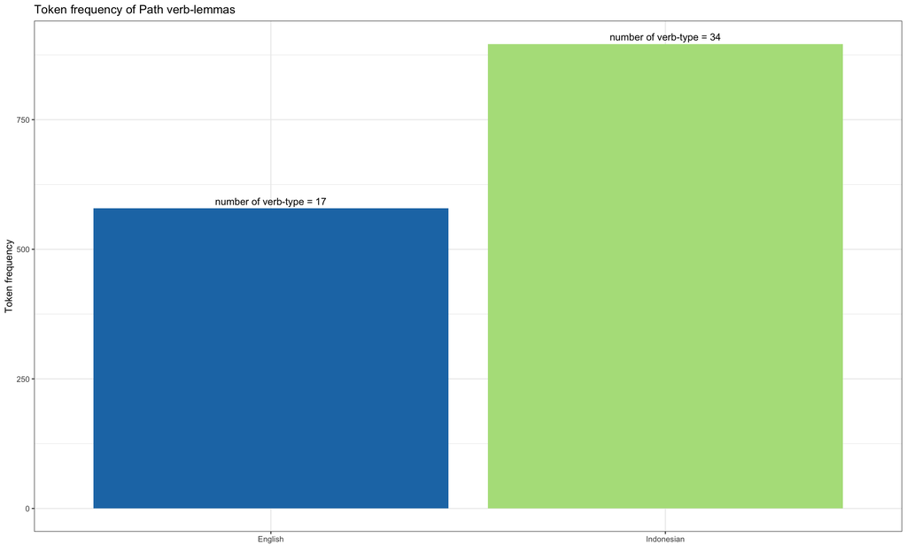

```r
pth %>%
  ggplot(aes(x = language, y = tokens)) +
  geom_col(fill = RColorBrewer::brewer.pal(12, name = "Paired")[2:3]) +
  geom_text(aes(label = paste("number of verb-type = ", type, sep = "")), vjust = -.5) +
  theme_bw() +
  labs(y = "Token frequency", x = "", title = "Token frequency of Path verb-lemmas") +
  ggsave("figs-joll/total-tokens-of-path-verbs.png", width = 6, height = 5)
```

### 2.2.5 Data in Table 2

Here are the codes to generate the content of the cells in **Table 2** in the paper.

```r
pth_idn_gloss <- c(menuju = "head toward/for", kembali = "return; go/come back", masuk = "go/come in; enter", berbalik = "turn over/upside down", keluar = "go/come out; exit", pulang = "return; go/come back", muncul = "emerge; appear", tiba = "arrive", turun = "go down; descend", jatuh = "fall", memasuki = "enter", menjauh = "move/get/stay (far) away", naik = "go up; rise; increase", mendekat = "approach; get close", berputar = "rotate; move around", menyusuri = "move along the edge/border/margin", meninggalkan = "leave behind/out; abandon", menuruni = "go down sth.; descend (into)", terjatuh = "fallend down (suddenly)", mengitari = "encircle; move in a circle around", maju = "move forward", menaiki = "go up (onto sth.)", pindah = "move; shift", beranjak = "move/shift one's position slightly", mundur = "go backward", melewati = "pass/go by/through", menghampiri = "come close/near to", menghambur = "scatter; disperse", menyeberangi = "go across/to the other side; cross sth.", membelok = "turn to the right/left", menelusuri = "follow/go along; trace", berpencar = "scatter; disperse", melintasi = "pass/flash by", mengelilingi = "go/revolve around")
pth_idn_gloss_df <- tibble(lemma = names(pth_idn_gloss),
                           gloss = unname(pth_idn_gloss))
path_idn_tokens1 <- path_idn_tokens %>% left_join(pth_idn_gloss_df, by = "lemma")
eng_pth_cell <- paste(paste("*", path_eng_tokens$lemma, "*", " (", path_eng_tokens$n, ")", sep = ""), collapse = ", ")
idn_pth_cell <- paste(paste("*", path_idn_tokens1$lemma, "*", " '", path_idn_tokens1$gloss, "' (", path_idn_tokens1$n, ")", sep = ""), collapse = ", ")

tibble(`---` = c("ENGLISH ...", eng_pth_cell, "INDONESIAN ...", idn_pth_cell)) %>%
  knitr::kable(caption = "Path verb-lemmas and their token frequencies in *Twilight*")
```

Path verb-lemmas and their token frequencies in *Twilight*

[output not shown]

[^1]: Universitas Udayana, Bali, Indonesia
[^2]: SIT Study Abroad Indonesia